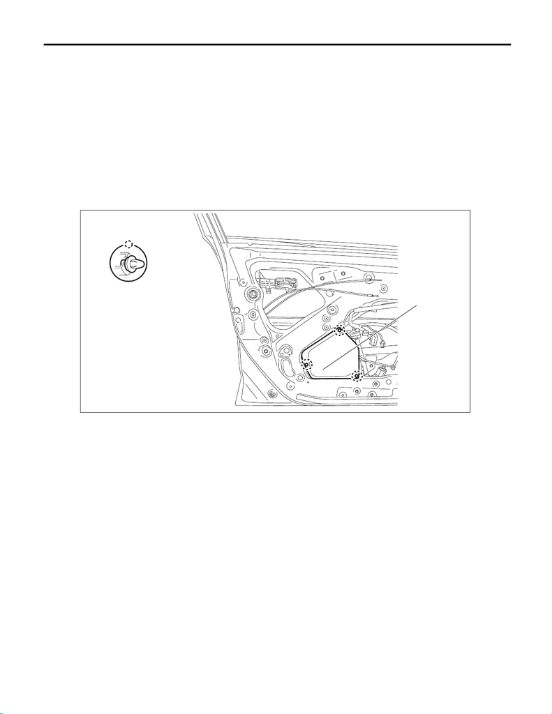

GW-19

Front Door Glass

GLASS/WINDOWS/MIRRORS

5. Front Door Glass

A: REMOVAL

1) Disconnect the ground cable from battery and wait for at least 60 seconds before starting work. <Ref. to

NT-5, BATTERY, NOTE, Note.>

NOTE:

For models other than STI model, disconnect the ground terminal from battery sensor.

2) Remove the trim panel - front door. <Ref. to EI-56, FRONT DOOR, REMOVAL, Door Trim.>

3) Remove the sealing cover - front door. <Ref. to EB-32, REMOVAL, Front Sealing Cover.>

4) Remove the front door inner pad (a).

CAUTION:

If the clip is damaged, replace it with a new part because the panel assembly - front door may be de-

formed.

5) Connect the battery ground terminal. <Ref. to NT-5, BATTERY, NOTE, Note.>

NOTE:

For models other than STI model, connect the ground terminal to battery sensor.

GW-01402

(a)

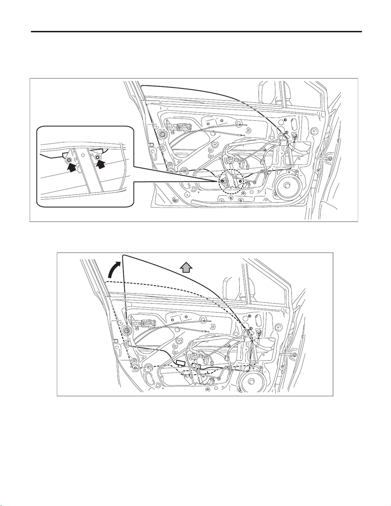

GW-20

Front Door Glass

GLASS/WINDOWS/MIRRORS

6) Remove the glass assembly - front door.

(1) Connect the switch - power window and then turn the ignition switch to ON.

(2) Operate the switch - power window to move the glass assembly - front door to the position where the

mounting bolts can be seen.

(3) Remove the mounting bolts from the glass assembly - front door.

(4) While tilting the glass, remove the glass assembly - front door.

CAUTION:

Avoid impact and damage to the glass assembly - front door.

GW-01403

GW-01404

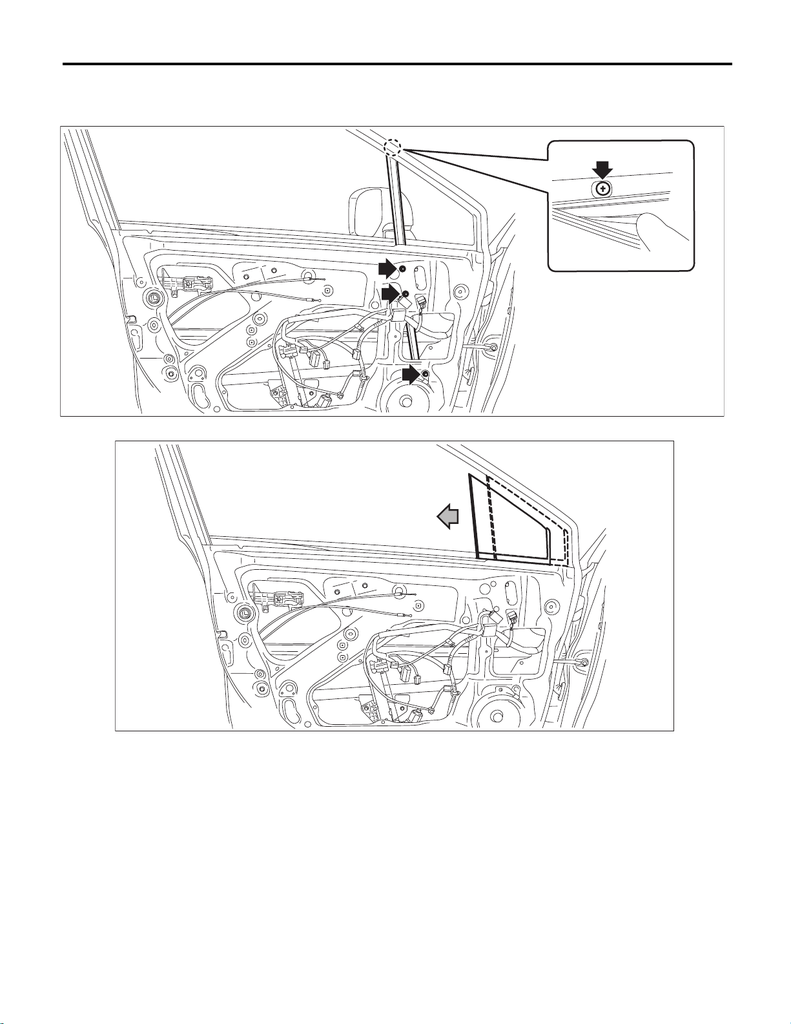

GW-21

Front Door Glass

GLASS/WINDOWS/MIRRORS

7) Remove the glass - front door partition.

(1) Remove the bolts and screws, and then remove the running channel - front door and the sash

COMPL - partition.

(2) Remove the glass - front door partition.

GW-01405

GW-01406

[figure not shown]

GW-22

Front Door Glass

GLASS/WINDOWS/MIRRORS

B: INSTALLATION

1) Install the glass - front door partition.

Tightening torque:

7.5 N·m (0.8 kgf-m, 5.5 ft-lb)

2) Install the running channel - front door and the sash COMPL - partition.

CAUTION:

Check that the running channel - front door is securely fixed to the panel assembly - front door and

to the sash COMPL - partition.

3) Install the glass assembly - front door.

Tightening torque:

7.5 N·m (0.8 kgf-m, 5.5 ft-lb)

4) Install the front door inner pad.

5) Install the sealing cover - front door.

6) Install the trim panel - front door.

7) Connect the battery ground terminal. <Ref. to NT-5, BATTERY, NOTE, Note.>

NOTE:

For models other than STI model, connect the ground terminal to battery sensor.